[figure not shown]

# Week 10 - Clustering

**Dr. David Elliott**

1. Hierarchical Clustering
2. DBSCAN

# 4. Hierarchical Clustering

Hierarchical clustering is an approach to clustering which does not require that we commit to a apriori number of clusters.

Instead we can determine the number of clusters using a tree-based representation of the observations, called a dendrogram<sup>1</sup>.

**Agglomerative** (or bottom-up) clustering is the most common type of hierarchical clustering and refers to the fact that a dendrogram (generally depicted as an upside-down tree) is built starting from the leaves and combining clusters up to the trunk<sup>1</sup>.

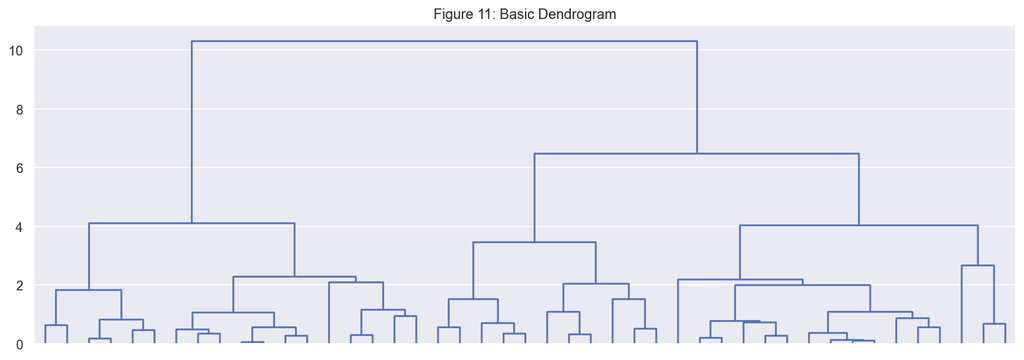

## Data Example

We will use the following data generated data.

There are three distinct classes, shown in separate colors. However, we will treat these class labels as unknown and will seek to cluster the observations in order to discover the classes from the data<sup>1</sup>.

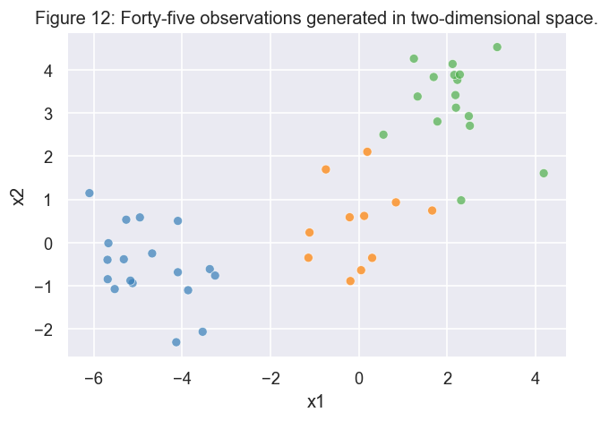

Each leaf of the dendrogram represents one of the 45 observations.

For any two observations, we can look for the point in the tree where branches containing those two observations are first fused.

The *height* of this fusion, indicates how different the two observations are. Observations that fuse at the bottom of the tree are quite similar to each other, whereas observations that fuse close to the top will generally be quite different<sup>1</sup>.

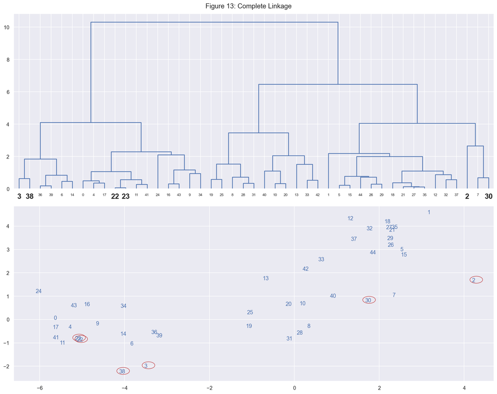

In order to identifying clusters using a dendrogram we make a horizontal cut across it. The distinct sets of observations beneath the cut can be interpreted as clusters.

A dendrogram can be used to obtain any number of clusters. In practice, it is common select by eye a sensible number of clusters based on the heights of the fusions and the number of clusters desired.

However, often the choice of where to cut the dendrogram is not so clear.

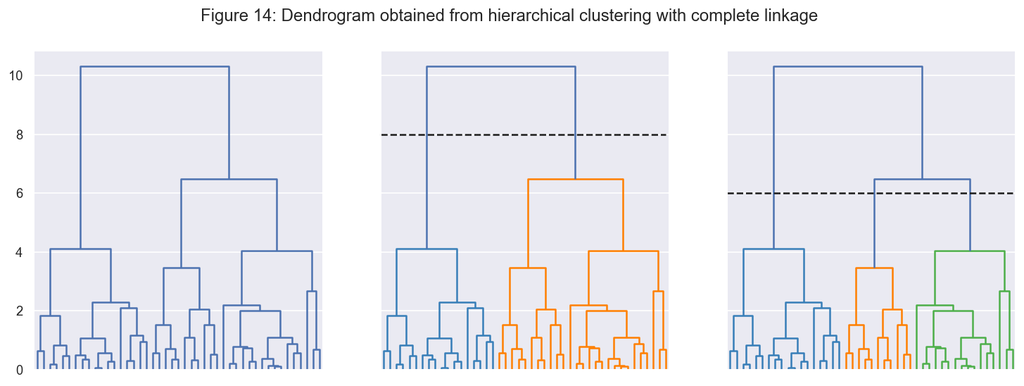

Heirarchical clustering dendrograms are oten used in combination with a **heat map**, which represent each individual value with a color<sup>2</sup>.

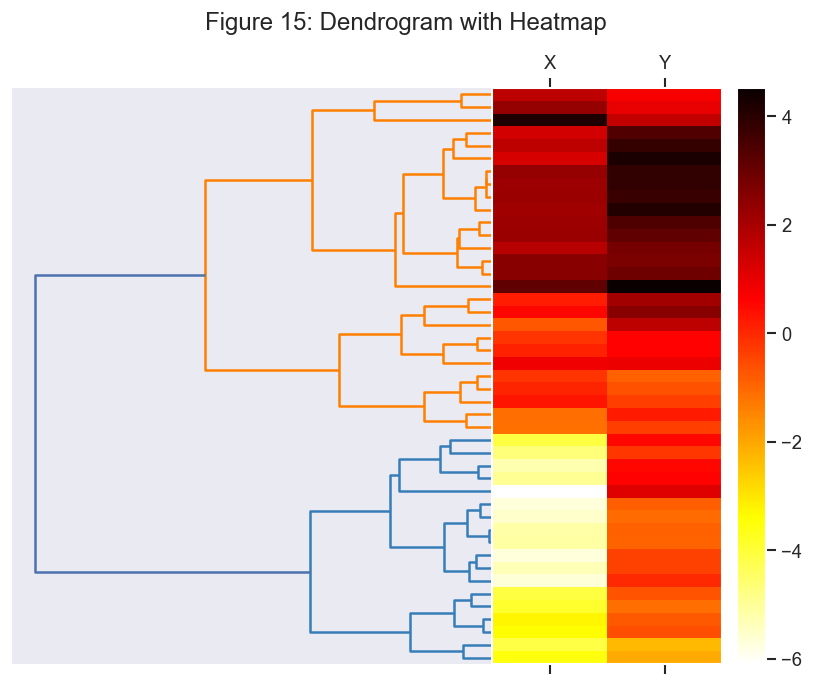

## The Hierarchical Clustering Algorithm<sup>1</sup>

1. Begin with n observations and a measure (such as Euclidean distance) of all the $({n \atop 2}) = \frac{n(n−1)}{2}$ pairwise dissimilarities. Treat each observation as its own cluster.
2. For $i = n, n−1 , \ldots , 2$:

   (a) Examine all pairwise inter-cluster dissimilarities among the $i$ clusters and identify the pair of clusters that are least dissimilar (that is, most similar). Fuse these two clusters. The dissimilarity between these two clusters indicates the height in the dendrogram at which the fusion should be placed.

   (b) Compute the new pairwise inter-cluster dissimilarities among the $i − 1$ remaining clusters.

[figure not shown]

## Dissimilarity Measure

For this to work, the dissimilarity between a pair of observations also needs to be extended to a pair of groups of observations (linkage).

**Complete**

- Maximal intercluster dissimilarity
- Compute all pairwise dissimilarities between the observations in cluster A and the observations in cluster B, and record the largest of these dissimilarities.

**Single**

- Minimal intercluster dissimilarity.
- Compute all pairwise dissimilarities between the observations in cluster A and the observations in cluster B, and record the smallest of these dissimilarities.
- Single linkage can result in extended, trailing clusters in which single observations are fused one-at-a-time.

```
Figure 16: Different Linkage Methods
```

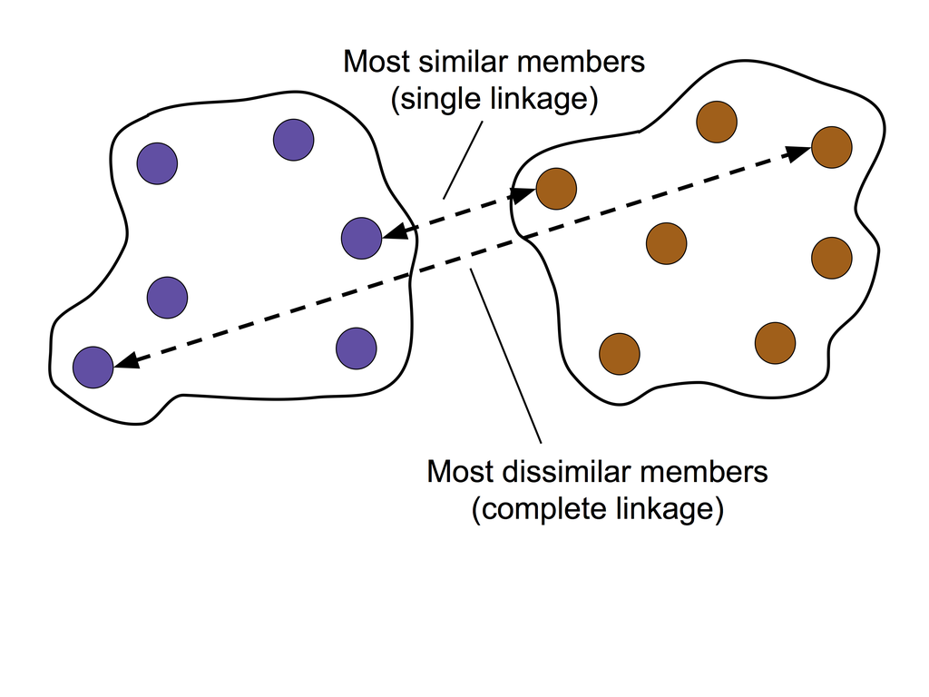

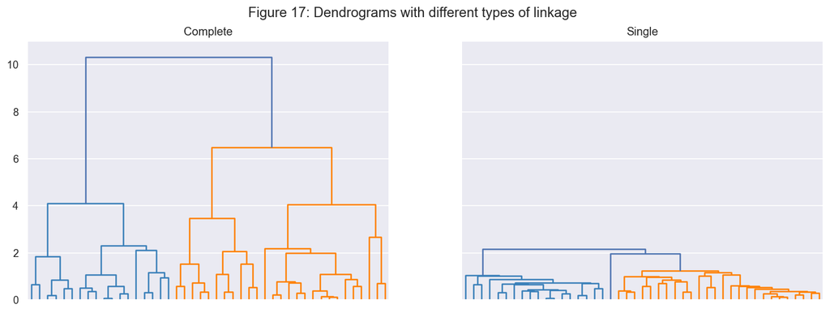

## Distance Measure

So far we have used Euclidean distance but other metrics exist.

**Correlation-based distance**<sup>1</sup>

- Considers two observations to be similar if their features are highly correlated.
- Values may be similar dispite being far apart in terms of Euclidean distance.

Choice is important but depends on data being clustered and the scientific question at hand.

# 5. DBSCAN

Density-based Spatial Clustering of Applications with Noise (DBSCAN) is density based clustering method.

For each instance:

- The algorithm counts how many instances are located within a small distance, $\epsilon$, of it<sup>3</sup>.
- If an instance has at least `min_samples` instances around it, then it is considered a **core instance**<sup>3</sup>.
- If a point has fewer neighbours than `min_samples` within $\epsilon$, but lies within the $\epsilon$ of a core instance, its considered a **border point**<sup>2</sup>.
- All points not a core point or border point are considered **noise points** (or anomaly)<sup>2</sup>.

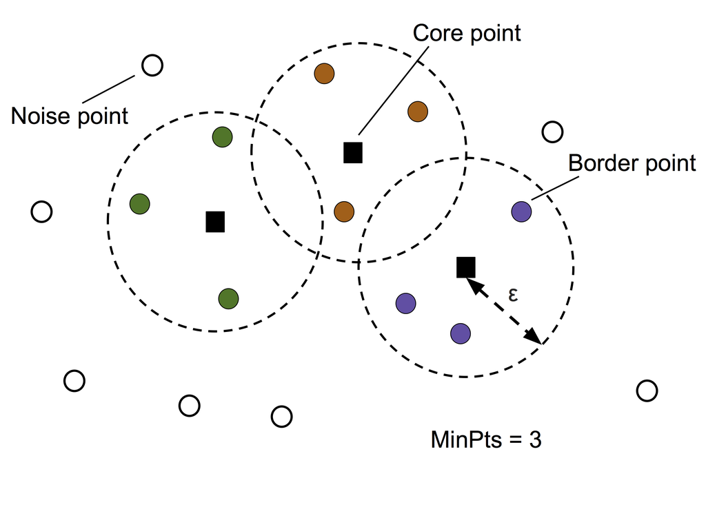

Once each point is labelled as either core, border, or noise, the algorithm<sup>2</sup>:

- Forms a separate cluster for each core point or connected group of core points provided they are no father than $\epsilon$ away from each other.
- Assigns each border point to the cluster of its corresponding core point.

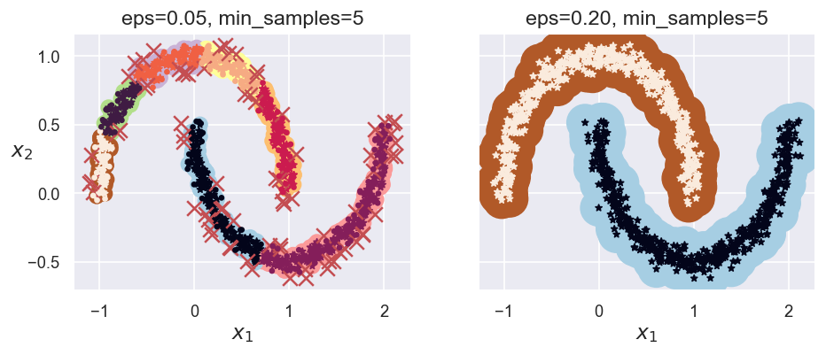

DBSCAN is not very good at making prediction of cluster assignment for new observations, so is more commonly used in a pipeline with another classification model<sup>3</sup>.

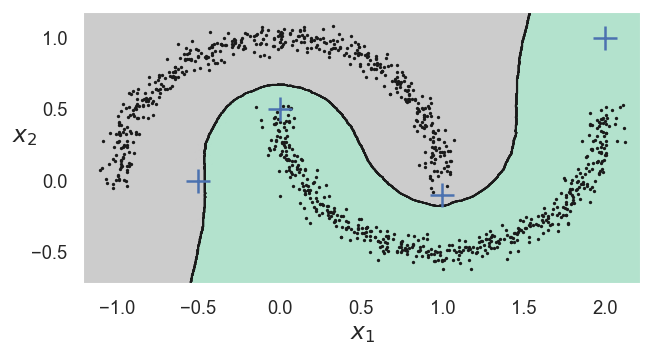

# Associated Exercises

Now might be a good time to try exercise 3.

# References

1. James, G., Witten, D., Hastie, T., & Tibshirani, R. (2013). An introduction to statistical learning (Vol. 112, p. 18). New York: springer.
2. Raschka, S., & Mirjalili, V. (2019). Python machine learning: Machine learning and deep learning with Python, scikit-learn, and TensorFlow 2. Packt Publishing Ltd.
3. Géron, A. (2019). Hands-on machine learning with Scikit-Learn, Keras, and TensorFlow: Concepts, tools, and techniques to build intelligent systems. O'Reilly Media.